# Diet Experiment sequence variants

# Downloading the data

If you do not have the raw data yet we will begin by downloading the raw FASTQ files from sequence read archive and renaming them to the original file names. In case you downloaded the files on your own you may have to edit the “id” column so it matches the `Sample_Name` column from the SRA run table. This is done automatically here:

You may want to play around with the `thread` argument to see which gives you the maximum download speed.

```r
library(mbtools)

downloaded <- fread("data/seaweed_files.csv") %>% download_files(threads = 8)
downloaded
```

[output not shown]

# Quality control

We will start by inspecting the general qualities of the sequencing files.

```r
library(mbtools)
pattern <- "(.+)_R(\\d+).fastq"
annotations <- c("id", "direction")
files <- find_read_files("data/seaweed/raw", pattern, annotations)
```

This gives us our list of raw inputs:

```r
files
```

[output not shown]

We can now set up our quality assessment.

```r
quals <- quality_control(files)
```

```
INFO [2019-02-21 15:24:53] Running quality assay for forward reads from 96 files.
```

[output not shown]

```
INFO [2019-02-21 15:25:06] Average per base error is 0.028% (mean score = 35.46).
INFO [2019-02-21 15:25:06] Mean per cycle entropy is 0.822 (in [0, 2]).
INFO [2019-02-21 15:25:06] On average we have 36441.32 ± 14033.16 reads per file.
INFO [2019-02-21 15:25:07] Running quality assay for reverse reads from 96 files.
```

[output not shown]

```
INFO [2019-02-21 15:25:20] Average per base error is 0.033% (mean score = 34.78).
INFO [2019-02-21 15:25:20] Mean per cycle entropy is 0.715 (in [0, 2]).
INFO [2019-02-21 15:25:20] On average we have 36441.32 ± 14033.16 reads per file.
```

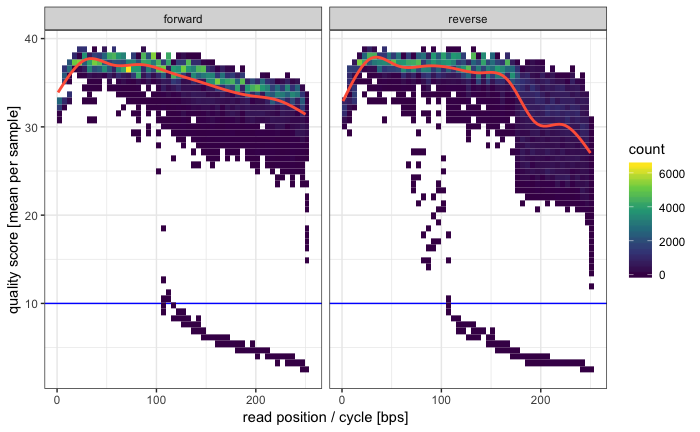

```r
quals$quality_plot
```

So we should probbaly trim off the first few bases. For the forward reads we so not have to trim too much, another 10 bp on 3’ should be fine. For the reverse we definitely see a decay after 170 bp so we trim that away.

# Processing with DADA2

We will start by setting up the configuration for our denoising workflow. We will combine preprocessing and denoising in a single step.

```r
config <- list(
  preprocess = config_preprocess(
    lefTrim = 10,
    truncLen = c(240, 170),
    out_dir = "data/seaweed/preprocessed"
  ),
  denoise = config_denoise(data_dir = "data/seaweed")
)
config
```

```
$preprocess
$preprocess$threads
[1] TRUE

$preprocess$out_dir
[1] "data/seaweed/preprocessed"

$preprocess$trimLeft
[1] 10

$preprocess$truncLen
[1] 240 170

$preprocess$maxEE
[1] 2

$preprocess$lefTrim
[1] 10


$denoise
$denoise$threads
[1] TRUE

$denoise$nbases
[1] 2.5e+08

$denoise$pool
[1] FALSE

$denoise$bootstrap_confidence
[1] 0.5

$denoise$taxa_db
[1] "https://zenodo.org/record/1172783/files/silva_nr_v132_train_set.fa.gz?download=1"

$denoise$species_db
[1] "https://zenodo.org/record/1172783/files/silva_species_assignment_v132.fa.gz?download=1"

$denoise$hash
[1] TRUE

$denoise$data_dir
[1] "data/seaweed"
```

Now let’s run the workflow.

```r
dada <- quals %>% preprocess(config$preprocess) %>% denoise(config$denoise)
```

[output not shown]

```
INFO [2019-02-21 15:39:36] Downloading taxa db to /var/folders/55/dv0p21y96g1cq84sr1zd3kym0000gr/T//Rtmp1WC9GC/species.fna.gz...
```

```
INFO [2019-02-21 15:50:37] Classified variants: Kingdom = 0.99543205177008, Phylum = 0.948229920060906, Class = 0.947849257708413, Order = 0.946707270650933, Family = 0.885420631899505, Genus = 0.628473543966502, Species = 0.0205557670346403
INFO [2019-02-21 15:50:37] Hashing 2627 sequence variants.
```

We will the entire analysis artifact for later use:

```r
saveRDS(dada, "data/seaweed/dada2.rds")
```

Now we can first inspect how well DADA2 did in the error rate estimation:

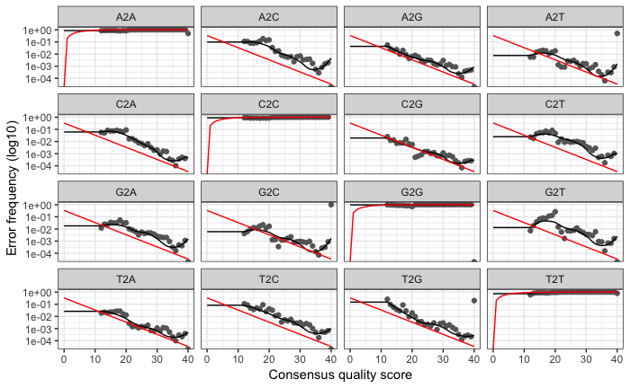

```r
dada$error_plots$all$forward
```

That looks good. And checking the reverse reads:

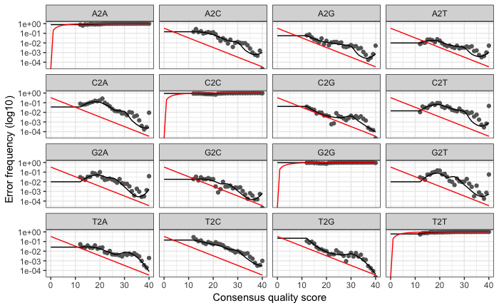

```r
dada$error_plots$all$reverse
```

We can also check how many reads we retained in each step:

```r
dada$passed_reads
dada$passed_reads[, summary(merged / preprocessed)]
```

```
   Min. 1st Qu.  Median    Mean 3rd Qu.    Max.
 0.0000  0.9740  0.9798  0.9530  0.9858  0.9955
```